# Changing Nature of Death in Infancy in the United States

#### Kaplan Meier Analysis 1995, 2007 and 2013 - Impact of Sex

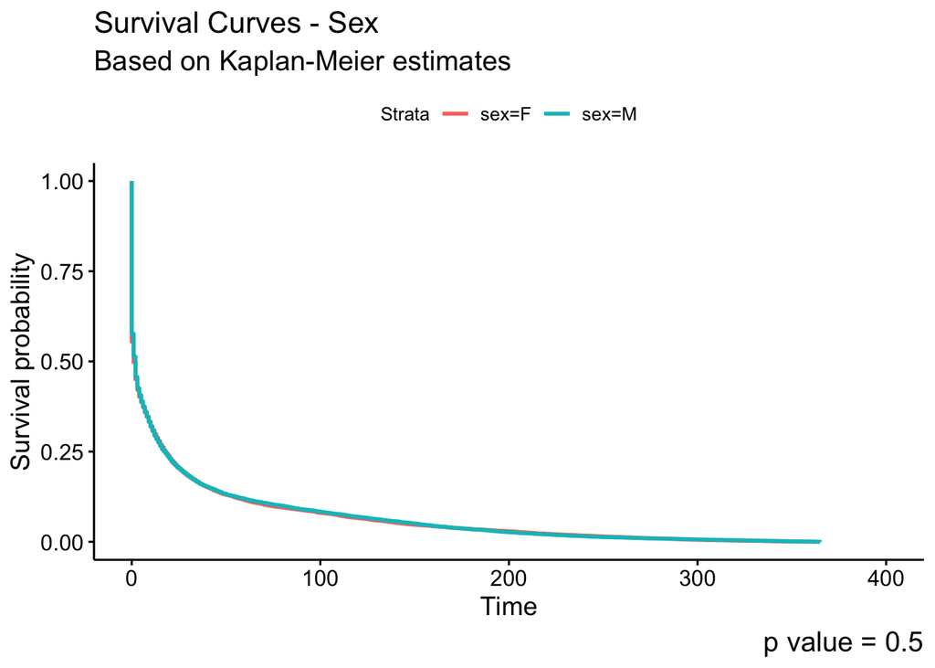

```r
km_infant_death_sex_fit <- survfit(Surv(aged, status) ~ sex, data=km_infant_deaths_VLBW)
#autoplot(km_infant_death_sex_fit)
#ggsurvplot(km_infant_death_sex_fit, data = km_infant_deaths_VLBW)
surv_plot_sex <- ggsurvplot(km_infant_death_sex_fit, data = km_infant_deaths_VLBW)
surv_plot_sex$plot <- surv_plot_sex$plot + labs(
  title    = "Survival Curves - Sex",
  subtitle = "Based on Kaplan-Meier estimates",
  caption  = "p value = 0.5"
  )
surv_plot_sex
```

#### Cox Proportional Hazard Model

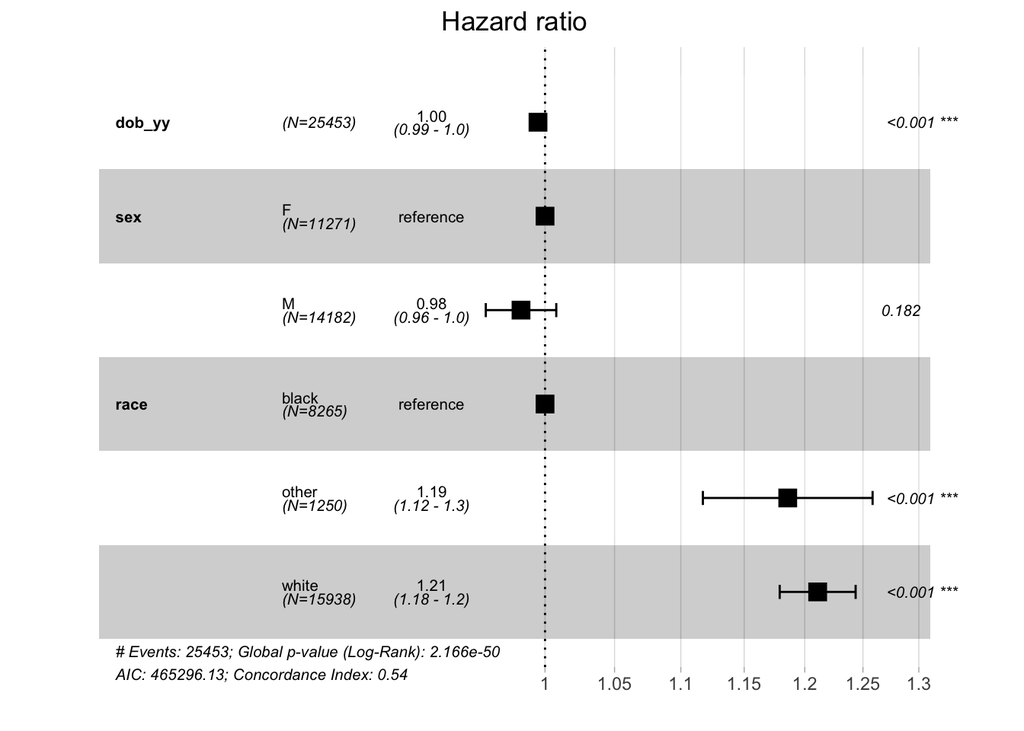

```r
infant_death_VLBW_cox <- coxph(Surv(aged, status) ~ dob_yy + sex + race , data = km_infant_deaths_VLBW)
#summary(infant_death_VLBW_cox)
ggforest(infant_death_VLBW_cox, data = km_infant_deaths_VLBW)
```

## Summary

- It appears that VLBW infants that died in infancy did see an increase in the time before death from **1995 through 2007**. _ However, timing of mortality more recently appears to be back to previous values.
  - This likely represents more infants living overall and not dying in infancy while those infants unlikely to respond to current therapies are dying early again.
    - Caffeine, CPAP, iNO may have have roles to play.
    - So may parental and health care giver attitudes towards resuscitation.
- Amongst the smallest birth weight infants there does seem to be an increasing time beofre death in the most recent era.
- African American infants appear to live longer then caucasian or other racial groups before death in infancy.